# Calibrarion of Ordinal Posterior Predictions

- Show All Code
- Hide All Code
- View Source

Author

Teemu Säilynoja

Published

February 4, 2023

Modified

February 27, 2025

This notebook reproduces and expands on the examples of predictive checks for ordinal data, shown in Section 6 of the article.

**Imports & options**

```r
library("bayesplot")
library("cmdstanr")
library("patchwork")
library("ggplot2")
library("khroma")
library("dplyr")


# Source for the modified reliability plot
source("code/R/helpers.R")
source("code/R/pava_plots.R")

theme_set(ppc_paper_theme())
bayesplot_theme_set(ppc_paper_theme())

SEED <- 236543
set.seed(SEED)
SAVE_FITS <- TRUE
```

In assessing the calibration, we use the ordinal nature of the data and use the cumulative posterior predictive mass function.

## 1 Data set

**Data generation**

```r
K <- 5
N <- 1500
sigma <- .5
c <- sample(1:K, N, replace = T)
x <- rnorm(N, c, sigma)
standata_gmm <- list(
  K = K,
  N = N,
  x = x,
  y = c,
  sigma = sigma
)
```

We generate data by drawing 1500 observations from a mixture of 5 Gaussians with means 1, 2, 3, 4, and 5, and standard deviation $0.5$.

$$\begin{align}
x_n &\sim \mathcal N\!\!\left(k, 0.5^2\right), &\text{for } n \in\{1,\dots,N\}\\
k &\sim \text{Categorical}(\theta_k),&\\
\theta_k &= \frac 1 K, &\text{for } k \in \{1, \dots, K\}.
\end{align}$$

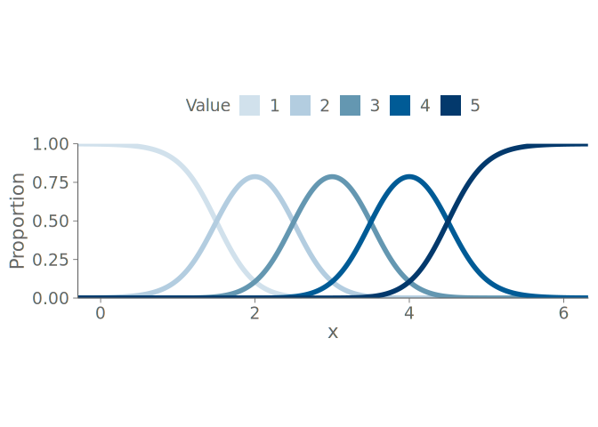

```r
data.frame(
  x = rep(seq(min(standata_gmm$x), max((standata_gmm$x)), .01), K),
  d = 1:K |> sapply(\(c) dnorm(seq(min(standata_gmm$x), max((standata_gmm$x)), .01), c, sigma)) |> c(),
  c = rep(1:K, each = length(seq(min(standata_gmm$x), max((standata_gmm$x)), .01)))
) |>
  group_by(x) |>
  mutate(percentage = d / sum(d)) |>
  ggplot() +
  geom_line(
    aes(
      x = x,
      y = percentage,
      color = as.factor(c),
      group = c
    ),
    linewidth = 2,
    key_glyph = "rect"
  ) +
  scale_color_manual(
    aesthetics = c("color"),
    values = unname(paper_colors[1:6])
  ) +
  labs(color = "Value", x = expression("x"), y = "Proportion") +
  coord_equal(ratio = 2, xlim = range(standata_gmm$x), ylim = c(0, 1), expand = FALSE) +
  theme(legend.position = "top")
```

## 2 Model

We fit two models to the data, both structured to first normalize the data and then fit a Gaussian mixture model (GMM) with K = 5` mixture components. The first model replicates a simple implementation error where standard deviation of the mixture components was incorrectly scaled.

**Read model code**

```r
gmm <- cmdstan_model("code/stan/gmm_classifier.stan")
gmm
```

```
data {
  int<lower=2> K;                   // Number of classes
  int<lower=0> N;                   // Total number of observations
  array[N] int<lower=1, upper=K> y; // Target classes
  vector[N] x;                      // Observed predictor values
  real<lower=0> sigma;              // User supplied standard deviation
  int correct_sigma;                // How to handle sigma, see below.
}

transformed data{
  vector[N] x_st;
  real Sigma;

  // Standardize data
  x_st = (x - mean(x)) / sd(x);

  // Maybe remember to scale sigma accordingly
  if (correct_sigma == 1) {
    Sigma = sigma / sd(x);
  } else {
    Sigma = sigma;
  }
}

parameters {
  // Inferred means.
  ordered[K] c;
  simplex[K] p_c;
}

model {
  // Prior
  c ~ normal(0,1);
  p_c ~ dirichlet(rep_vector(1,K));

  // Likelihood
  for (n in 1:N) {
    target += normal_lpdf(x_st[n] | c[y[n]], Sigma);
  }
}

generated quantities {
  // Posterior predictive sample
  vector[N] yrep;
  // For each observation, posterior predictive mass of classes
  array[N] vector[K] ppm;

  for (n in 1:N) {
    for (k in 1:K) {
      ppm[n, k] = normal_lpdf(x_st[n] | c[k], Sigma);
    }
    ppm[n, ] = softmax(ppm[n, ]);
    yrep[n] = categorical_rng(ppm[n, ]);
  }
}
```

**run CmdStanR**

```r
fit_1 <- gmm$sample(
  data = c(standata_gmm, list(correct_sigma = 0)),
  parallel_chains = 4,
  refresh = 0,
  seed = SEED,
  show_messages = FALSE
)

fit_2 <- gmm$sample(
  data = c(standata_gmm, list(correct_sigma = 1)),
  parallel_chains = 4,
  refresh = 0,
  seed = SEED,
  show_messages = FALSE
)
```

```r
p_1 <- matrix(colMeans(fit_1$draws(variables = "ppm", format = "matrix")), ncol = K)

p_2 <- matrix(colMeans(fit_2$draws(variables = "ppm", format = "matrix")), ncol = K)
```

## 3 Predictive checks

First, we use a bar graph to visualize the relative frequencies of the groups in the observation and the predictive draws. We don’t see much difference between the models, and all of the observations seem to fall within the credible intervals of the predictions of both models.

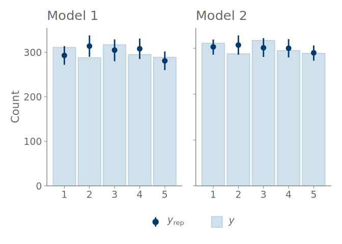

```r
p2 <- ppc_bars(
  y = as.numeric(c),
  yrep = fit_2$draws(variables = "yrep", format = "matrix")
) +
  ggtitle("Model 2") +
  theme(
    axis.title.y = element_blank(),
    axis.text.y = element_blank()
  )

p1 <- ppc_bars(
  y = as.numeric(c),
  yrep = fit_1$draws(variables = "yrep", format = "matrix")
) +
  ggtitle("Model 1")

(p1 + p2) + plot_layout(guides = "collect") & theme(legend.position = "bottom")
```

When using the PAV-adjusted calibration plots, we see that the first model, with the initial implementation error is under confident (S-shaped calibration curves) in its predictions, and assigns probabilities too close to 0.5 to many cases that the other model is better able to separate towards the observed outcomes.

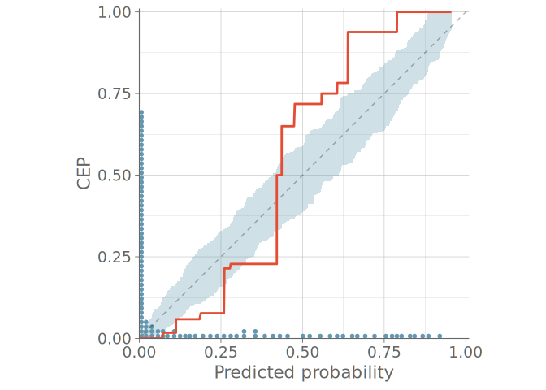

```r
ppc_calibration_pava(
  y = as.numeric(c <= 1),
  p = p_1[, 1],
  quantiles = 100,
  dot_scale = .7,
  fill_alpha = .3,
  cep_line_color = paper_colors["orange"]
)
```

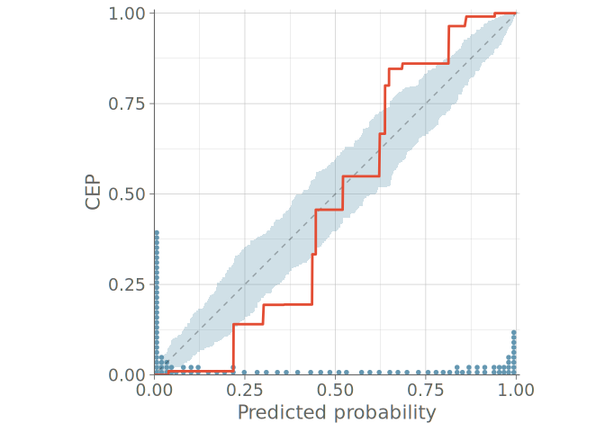

```r
ppc_calibration_pava(
  y = as.numeric(c <= 2),
  p = pmin(1, rowSums(p_1[, 1:2])),
  quantiles = 100,
  dot_scale = .4,
  fill_alpha = .3,
  cep_line_color = paper_colors["orange"]
)
```

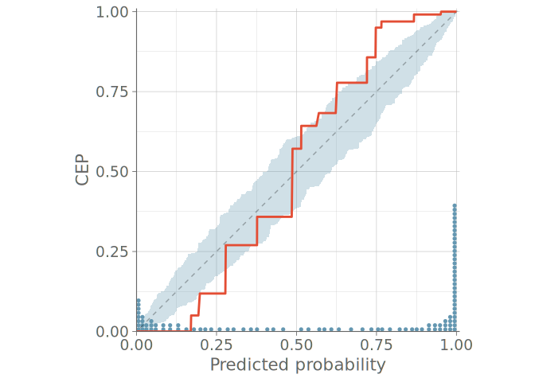

```r
ppc_calibration_pava(
  y = as.numeric(c <= 3),
  p = pmin(1, rowSums(p_1[, 1:3])),
  quantiles = 100,
  dot_scale = .4,
  fill_alpha = .3,
  cep_line_color = paper_colors["orange"]
)
```

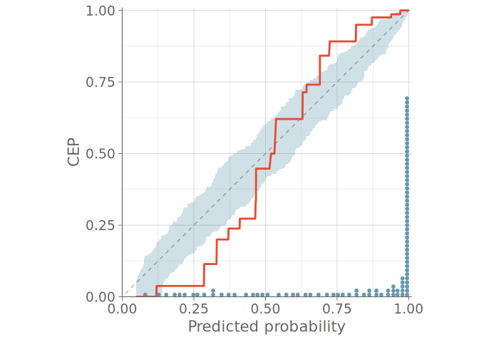

```r
ppc_calibration_pava(
  y = as.numeric(c <= 4),
  p = pmin(1, rowSums(p_1[, 1:4])),
  quantiles = 100,
  dot_scale = .7,
  fill_alpha = .3,
  cep_line_color = paper_colors["orange"]
)
```

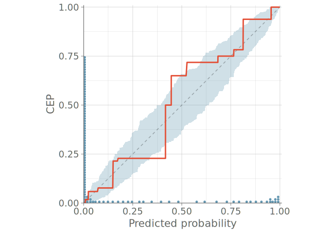

```r
ppc_calibration_pava(
  y = as.numeric(c <= 1),
  p = p_2[, 1],
  quantiles = 100,
  dot_scale = .75,
  fill_alpha = .3,
  cep_line_color = paper_colors["orange"]
)
```

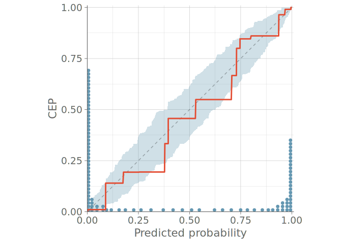

```r
ppc_calibration_pava(
  y = as.numeric(c <= 2),
  p = pmin(1, rowSums(p_2[, 1:2])),
  quantiles = 100,
  dot_scale = .7,
  fill_alpha = .3,
  cep_line_color = paper_colors["orange"]
)
```

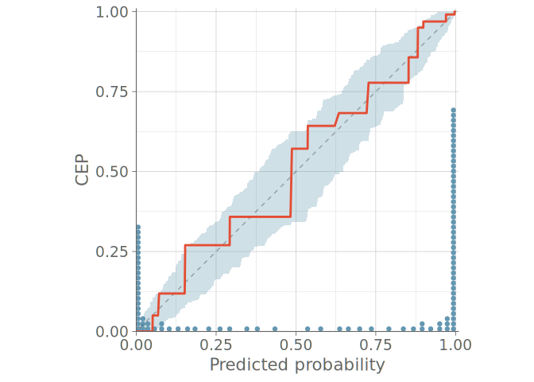

```r
ppc_calibration_pava(
  y = as.numeric(c <= 3),
  p = pmin(1, rowSums(p_2[, 1:3])),
  quantiles = 100,
  dot_scale = .7,
  fill_alpha = .3,
  cep_line_color = paper_colors["orange"]
)
```

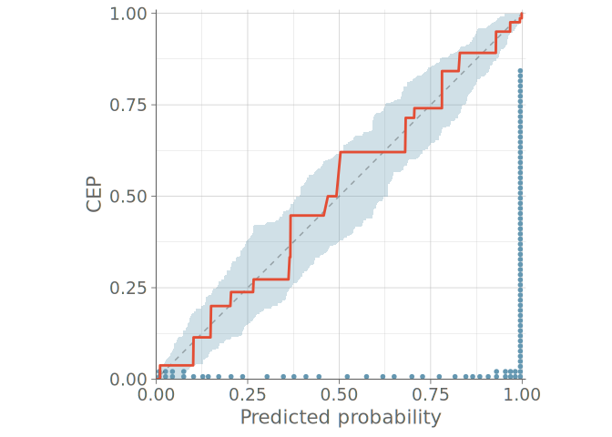

```r
ppc_calibration_pava(
  y = as.numeric(c <= 4),
  p = pmin(1, rowSums(p_2[, 1:4])),
  quantiles = 100,
  dot_scale = .85,
  fill_alpha = .3,
  cep_line_color = paper_colors["orange"]
)
```